# Part II - Ford GoBike Data Exploration

## by Simba Pfaira

## Investigation Overview

My main goal is to find relationships between trip count, trip durations, user types and member gender.

## Dataset Overview

This project explores the San Francisco Bay Area Bike Share dataset which contains information about trips taken by riders, their subscription type, their age, their gender, stations of starting and ending trips, duration of trips among other attributes. The dataset contains information on 183412 bike trips and has 16 attributes for each bike trip.

## Visualizaton 1

### The relationship between user age and number of trips taken

The histogram below depicts a unimodal distribution with the highest number of the people who used the bike sharing system being between 25 and 35 years old.

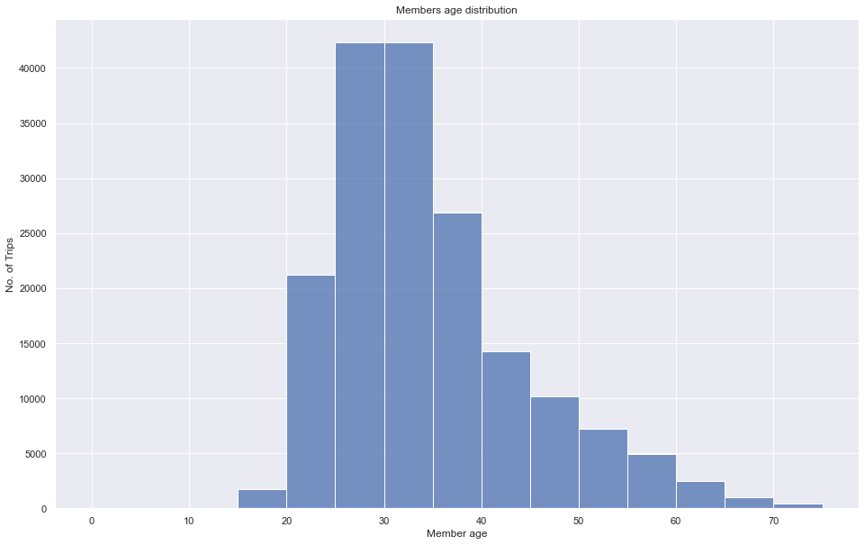

## Visualization 2

### The distribution of trips over the days of the week

From the visualization we can see that most of the trips occurred during the weekdays than the weekends. This is expected as weekdays has more activity than weekends, people going to school, work e.t.c

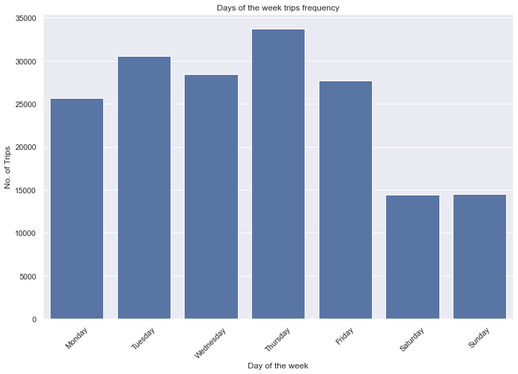

## Visualization 3

### The relationship between average trip duration and the day of the week

The average highest duration of the trips are on Saturday and Sunday. This might suggest that people will be taking trips for fun or exercise during the weekend as they be having free time other than the weekdays.

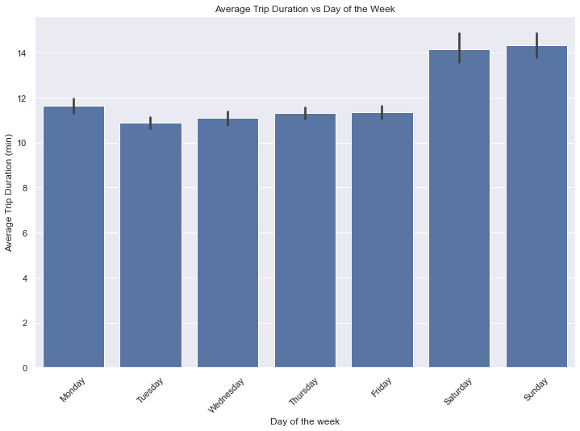

## Visualization 4

### The relationship between user type and trip duration

From this chart below it shows that the average of the trip duration of customers is clearly greater than the average duration of the subscribers.

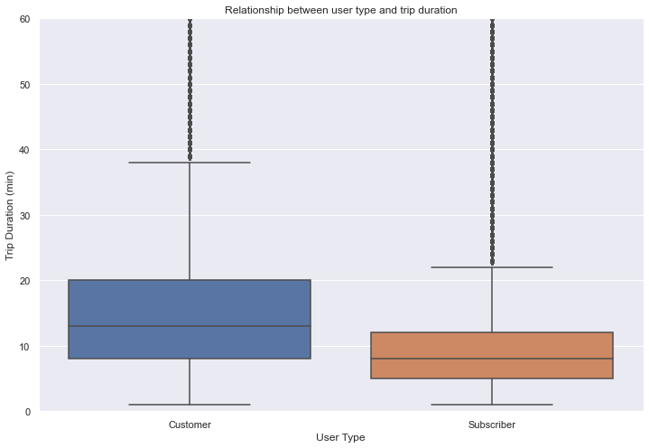

## Visualization 5

### The distribution of trips duration for each gender for each user type

The most trips are between 5-15 minutes and on age of 20-45 years for both customers and subscribers.

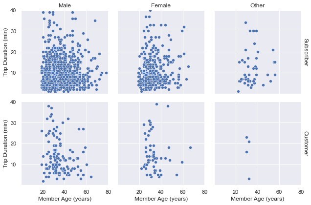

## Conclusion

The main conclusions that can be inferred from this dataset are-:

- bike trips are mostly short, between 5 or 15 minutes long.
- most of the users are between 20 and 40 years of age.
- the average trip duration during weekends is longer than that during the weekdays.
- customers use the bikes for longer periods than subscribers and the trips usually takes place on weekend.